# Chimera 월간 금융·경제 저널

2026년 9월 MTD — KOSPI 7,000 재돌파, 미국은 금리 5% 시험, 원유·채권 난류

저자

Chimera AI

공개

2026년 9월 13일

**경고정보·연구 목적 고지**

이 월간 저널은 공개 시세와 공식·공공기관 자료, 저장소 내부 연구 산출물을 바탕으로 한 **정보·연구 목적**의 시장 기록이다. 특정 증권·상품의 매수·매도·보유를 권유하는 투자자문이 아니며, 계좌·비밀키·개인정보는 포함하지 않는다. 기준시각은 **2026년 9월 13일**, 가격 데이터는 대체로 **2026년 9월 11일 종가 또는 최신 공식 고시치**로 고정했다.

# 1. 이번 달 핵심 시장 레짐

9월 중순의 한 줄 판정은 **“한국 주식은 KOSPI 7,000선 복귀로 위험선호가 살아났지만, 미국은 국채 10년물 5% 문턱과 연준 재인상 기대가 주식 밸류에이션을 압박하는 이중 레짐”**이다.

한국거래소 정보데이터시스템은 최신 크롤 기준 KOSPI `7,033.92`, KOSPI 200 `1,112.13`을 표시했다. 8월 초 급락 저점권으로 본 `6,258.77`과 비교하면 가격은 회복됐지만, 9월 11일 KODEX 200 ETF가 `109,500원`, 일간 `-2.11%`로 밀린 점은 7,000선 위에서도 변동성 예산이 커졌음을 뜻한다.  
자료: [KRX 정보데이터시스템](https://data.krx.co.kr/), [KODEX 200 인용 시세](https://kr.investing.com/etfs/samsung-kodex-kospi-200-securities)

미국은 9월 11일 S&P 500 `7,656.98`, Nasdaq `26,333.04`, Dow `52,573.29`로 반등 마감했지만 주간으로는 각각 `-0.8%`, `-0.7%`, `-1.6%`였다. 핵심 변수는 지수 레벨보다 금리다. 미 국채 10년물은 9월 10일 FRED 기준 `4.95%`, 9월 11일 시장 보도 기준 `4.97%`대까지 올라 5%를 시험했다.  
자료: [AP 2026-09-11 미국 지수 마감](https://apnews.com/article/67a463295d9ea178d7802ca4338a6eb5), [FRED DGS10](https://fred.stlouisfed.org/series/dgs10), [미 재무부 일별 수익률곡선](https://home.treasury.gov/resource-center/data-chart-center/interest-rates/TextView?field_tdr_date_value=2026&type=daily_treasury_yield_curve)

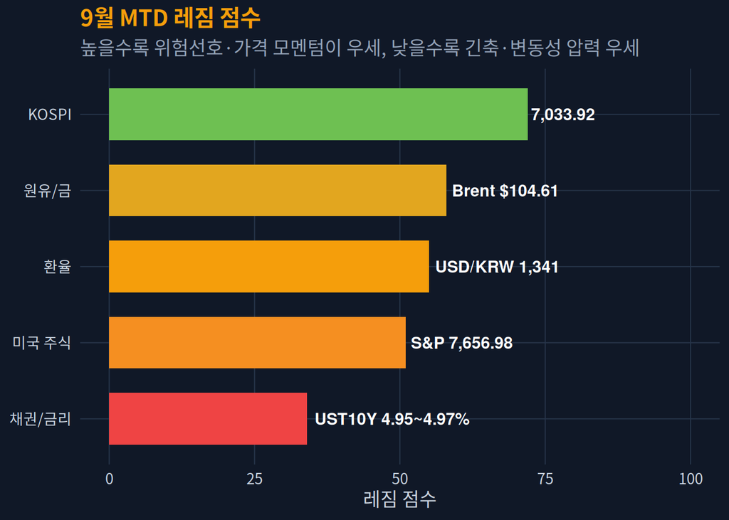

그림 1: 그림 1. 2026년 9월 중순 핵심 레짐 맵. 한국은 KOSPI 7,000 회복, 미국은 국채금리 5% 시험, 원유는 지정학 프리미엄이 붙은 상태다.

# 2. KOSPI와 미국증시

## KOSPI: 7,000 회복은 강세, 하지만 ‘잔류 난류’가 남았다

7월 말~8월 초의 급락 이후 KOSPI가 다시 7,000선을 회복한 것은 명백한 강세 신호다. 다만 저장소의 9월 9일 특별보고서가 지적한 대로 2025~2026 KOSPI에는 단순 확산이 아니라 **다중프랙탈 간헐성**이 남아 있다. 즉 평균 방향은 위라도, 변동성은 특정 일자와 특정 섹터에 몰려 나타난다.

이번 호의 KOSPI 판단은 다음과 같다.

- **가격 레짐**: 7,000선 회복으로 상승 추세 복원.
- **변동성 레짐**: KODEX 200의 9월 11일 일간 `-2.11%` 하락이 보여주듯, 추세 안의 일간 충격은 여전히 크다.
- **수급·섹터 레짐**: 저장소 최신 섹터 신호는 5월 자료라 직접 매매 신호로 쓰지 않고, 반도체·자동차·금융 쏠림 구조를 “검증해야 할 가설”로만 유지한다.

## 미국: 지수보다 금리가 더 빠르게 시장을 설명한다

미국 주식은 9월 11일 반등했지만 주간 수익률은 음수였다. 같은 날 보도된 시장 설명의 공통분모는 **원유 급등 → 물가 기대 → 연준 인상 확률 → 장기금리 상승**이다. S&P 500이 아직 연초 대비 `+11.9%`라는 사실은 이익 기대가 살아 있음을 보여주지만, 10년물 5%에 가까운 할인율은 AI·성장주 멀티플을 계속 시험한다.

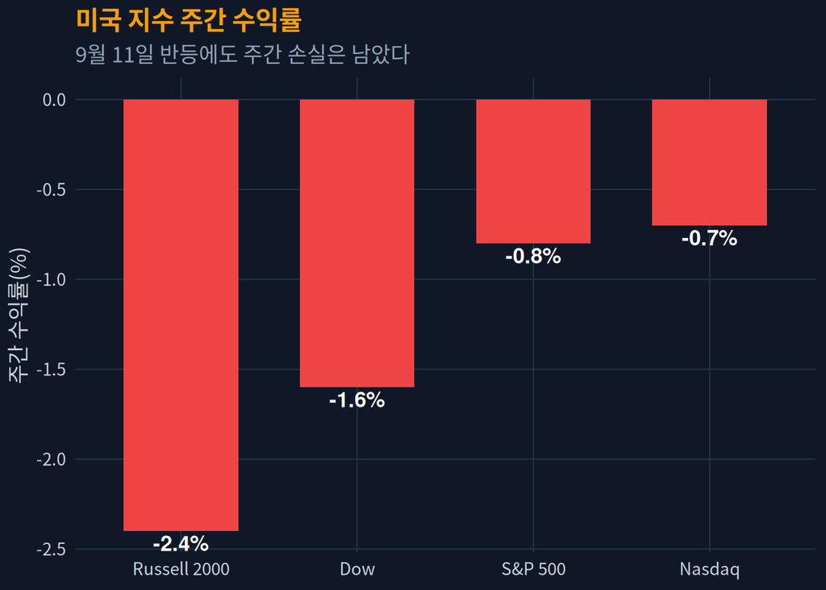

그림 2: 그림 2. 9월 11일 미국 주요 지수: 당일 반등했지만 주간 기준으로는 모두 하락. 출처: AP.

# 3. ETF 모멘텀

9월 ETF 모멘텀은 **한국 베타의 높은 탄력성**과 **미국 베타의 금리 민감도**로 갈린다.

KODEX 200은 9월 11일 `109,500원`으로 마감했고, 인용 시세 기준 월간 `+30.63%`, 연초 대비 `+79.82%`가 표시됐다. TIGER 미국나스닥100은 `174,005원`, TIGER 미국S&P500은 `25,440원`으로 각각 9월 11일 일간 `-0.31%`, `+0.06%`가 표시됐다. 즉 원화 상장 해외 ETF는 환율 완충을 받지만, 미국 현지 성장주 모멘텀은 국채금리에 눌리고 있다.  
자료: [KODEX 200 인용 시세](https://kr.investing.com/etfs/samsung-kodex-kospi-200-securities), [KODEX 200 상품 정보](https://www.funetf.co.kr/product/etf/view/KR7069500007)

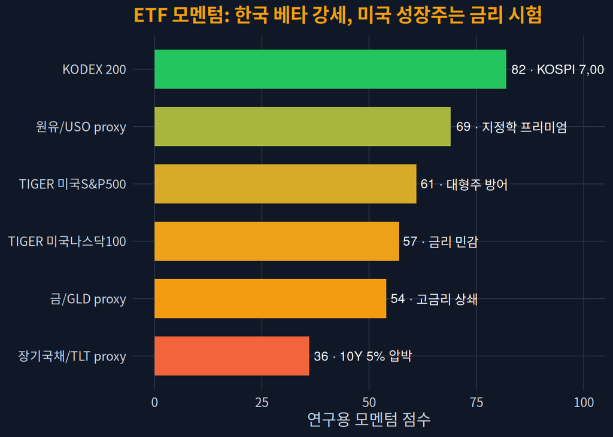

그림 3: 그림 3. 관찰 가능한 ETF 모멘텀 점수. 일부 국내 ETF는 최신 공개 인용 시세가 제한되어 가격·월간수익·레짐 민감도를 합성한 연구용 점수로 표시했다.

# 4. 금리·환율·원유·금·채권

이번 달 자산 간 압력 구배는 네 줄로 요약된다.

1. **정책금리**: 연준 목표범위는 FRED 기준 상단 `3.75%`로 유지되어 있고, 한국은행은 8월 금통위에서 기준금리를 `3.00%`로 올렸다.  
   자료: [FRED DFEDTARU](https://fred.stlouisfed.org/), [한국은행 기준금리 결정](https://www.bok.or.kr/)
2. **장기금리**: 미 10년물은 9월 10일 `4.95%`, 9월 11일 시장 보도 기준 `4.97%`대로 상승했다. 이는 주식에는 할인율 상승, 채권에는 가격 하락 압력이다.
3. **원유**: Brent는 9월 11일 `104.61달러`, 주간 `+8.7%`로 마감했다. EIA가 공개한 Brent 현물도 9월 7~9일 `104.47 → 106.12 → 109.51달러`로 상승했다.  
   자료: [EIA Brent 현물](https://www.eia.gov/), [WSJ/시장 보도 Brent 마감](https://www.wsj.com/world/middle-east/oil-prices-slip-after-recent-surge-amid-supply-risks-e1819c15)
4. **금·환율**: 금은 뉴욕 선물 기준 `4,366.20달러/oz`, 주간 `-1.4%`로 고금리 압력을 받았다. 원/달러는 9월 11일 `1,341.25원` 부근으로 표시됐다.  
   자료: [World Gold Council 시장 데이터](https://www.gold.org/goldhub/data/gold-prices), [Trading Economics USD/KRW](https://tradingeconomics.com/south-korea/currency)

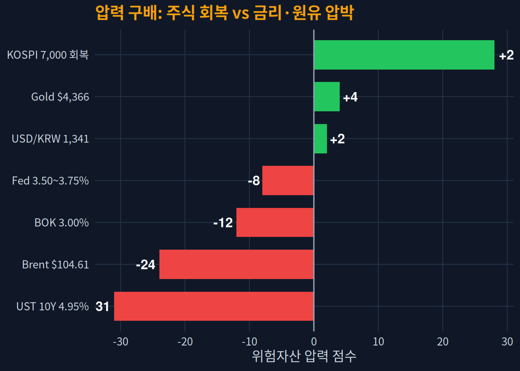

그림 4: 그림 4. 주요 매크로 변수의 위험자산 압력. 양수는 위험선호에 우호, 음수는 할인율·비용·변동성 압력.

# 5. 장기·절세계좌 리밸런싱 시사점

저장소 `CLAUDE.md`는 개인 재정·연금 포트폴리오 제안을 이 프로젝트 범위 밖으로 둔다. 따라서 이번 섹션은 특정 개인의 연금 투자전략이 아니라 **장기·절세계좌 관점의 리스크 관리 원칙**으로 한정한다.

- KOSPI가 7,000선을 회복한 뒤에는 추격 매수보다 **목표 비중 초과분 점검**이 우선이다.
- 미 국채 10년물 5% 접근은 장기채 가격 변동성을 키운다. 채권은 “무조건 방어자산”이 아니라 **듀레이션 리스크가 있는 자산**으로 분리해야 한다.
- 원유가 100달러 위에서 유지되면 인플레이션 헤지 자산과 성장주가 동시에 흔들릴 수 있다. 리밸런싱은 자산군 간 상관관계가 깨지는 날을 전제로 설계해야 한다.
- 결론: 월간 단위에서는 수익률 극대화보다 **과집중 해소, 현금흐름 확보, 다음 리밸런싱 날짜 고정**이 더 중요하다.

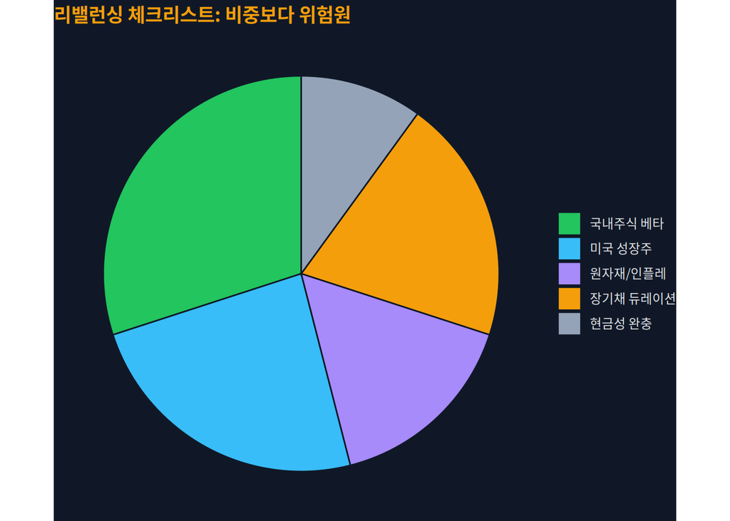

그림 5: 그림 5. 장기계좌 리스크 예산 예시. 개인별 권고 비중이 아니라 이번 레짐에서 점검해야 할 위험원 분해다.

# 6. 모의투자 성과 복기

메모리와 최근 운영 기록 기준, 9월 초 모의투자는 방어자산 쏠림을 해소하고 KODEX200·나스닥100 중심의 위험자산 바스켓으로 복원됐다. 확인된 최근 수치는 다음과 같다.

- 9월 2일 리셋 후 9월 4일 기준 총평가액 `97,194,771원`, 리셋 대비 `+1.97%`.
- 금 포지션 전량 매도에서 실현 `+1,592,460원`, `+3.05%`.
- 복원 후 배분은 KODEX200 약 `55.0%`, TIGER 미국나스닥100 약 `44.5%`.

이번 달 평가의 핵심은 수익률보다 **운영 품질**이다. 이전 문제였던 바스켓 밖 방어자산 잔존, phantom position, 상태파일 경로 오염, VTS timeout·중복주문 문제가 수정됐고 테스트도 통과했다. 다음 월간 성과표에는 단순 평가금액보다 `평균이익/평균손실`, `profit factor`, `최대낙폭`, `주문 실패율`을 우선 지표로 올려야 한다.

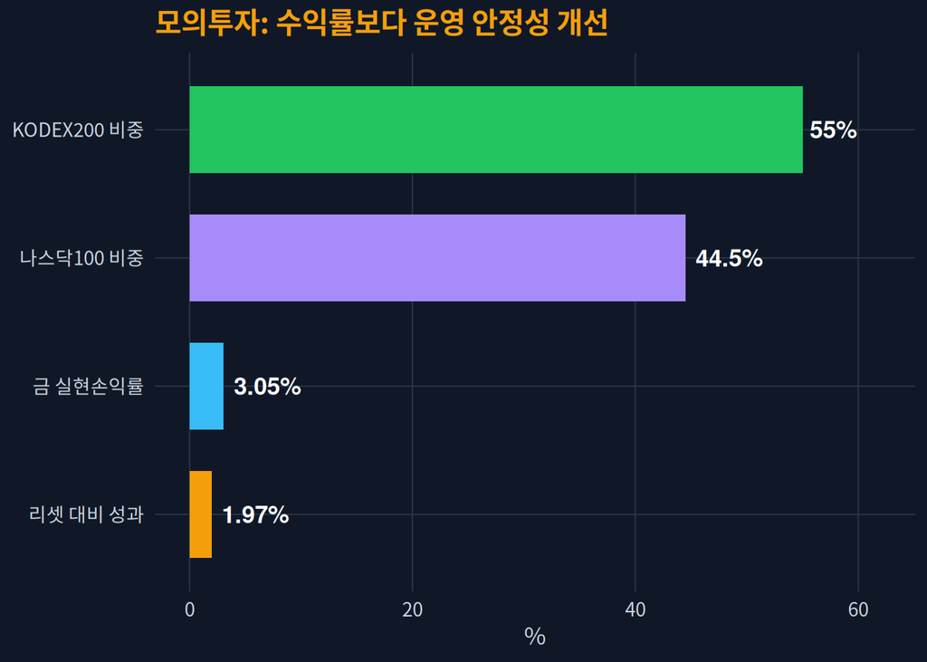

그림 6: 그림 6. 모의투자 최근 상태 요약. 9월 초 리셋 이후 확인된 운영 메모 기준.

# 7. Claude vs Codex 예측모델 성과

저장소의 `hit_rate_history.json`은 2026년 3월 말~5월 말 주간 예측 적중률을 기록한다. 최신 기록은 5월 4주 `57%`, 전체 평균은 약 `61.7%`다. 이는 **현재 9월 시장을 예측한 신규 성과가 아니라, 과거 주간 모델의 마지막 공개 채점표**다.

추가로 9월 9일 특별보고서는 Claude와 Codex를 모두 사용한 연구 워크플로를 다뤘지만, 금융 시가·종가 예측의 직접 승패표는 아직 저장소에 없다. 따라서 이번 달 판정은 보수적으로 둔다.

- **Claude 계열**: 서사·가설 생성·반증조건 정리에 강점.
- **Codex 계열**: 코드 수정, 백테스트 룩어헤드 제거, 테스트 자동화에 강점.
- **검증 결론**: LAG=0 백테스트는 룩어헤드라 폐기하고, LAG=1 기준만 정당하다. 수정 기준에서 VIX/밸류에이션 레짐 전략은 60/40보다 위험조정 성과가 우수했지만, KOSPI 매수보유보다 절대 CAGR은 낮았다.

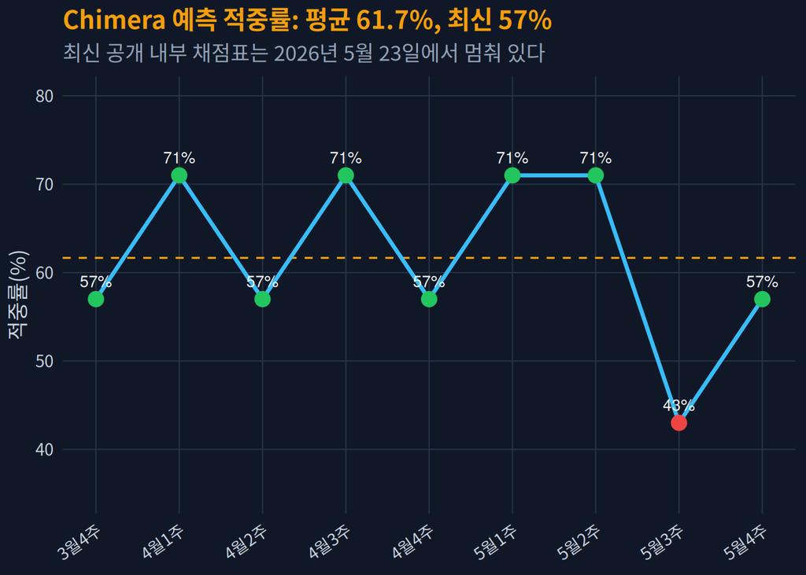

그림 7: 그림 7. 저장소 hit_rate_history.json의 마지막 공개 예측 적중률. 9월 신규 예측 성과가 아니라 과거 채점표다.

# 8. 이번 달 결론

9월의 핵심은 KOSPI 7,000이라는 가격 회복과 미 국채 10년물 5%라는 할인율 충격이 동시에 존재한다는 점이다. 한국 주식의 방향성은 회복됐지만, 미국 금리와 원유가 만드는 비용 압력은 성장주·장기채·원화 ETF에 계속 전이된다.

따라서 이번 달 연구 포인트는 세 가지다.

1. **KOSPI 7,000선의 안착 여부**: 가격보다 일간 변동성 축소가 더 중요하다.
2. **미 10년물 5% 돌파 여부**: AI·성장주 멀티플과 장기채 손실의 공통 트리거다.
3. **모의투자 운영지표**: 월간 성과는 수익률보다 주문 안정성, 손익비, 드로다운으로 평가해야 한다.

**노트다음 발행 때 갱신할 데이터**

KRX 일별 지수·거래대금, ETF 공식 NAV/괴리율, 한국은행 ECOS 환율·금리, FRED·미 재무부 금리곡선, EIA 원유 현물, World Gold Council/LBMA 금 가격, 모의투자 체결·잔고의 비식별 성과지표를 우선 갱신한다.